# ROC Curve and Multivariate Regression

hiox-tech

2026-08-06

# 1 Analysis Objectives

The diagnostic ability of a single marker is often limited; combining multiple markers can improve the overall discrimination. Besides single-marker ROC, the `roc()` function in `ivdtools` also supports combining multiple markers into a joint score with multivariate logistic regression (`mlr()`), computing its AUC, and predicting the positive probability for new samples.

This document demonstrates the joint analysis of two markers (x1, x2): first compare the single-marker AUCs, then fit a multivariate logistic regression model, draw the multi-curve ROC, and predict new samples. The AUC of the joint model on the training data is the **apparent performance** and should be validated on independent data before generalization; the reference variable must be binary.

```r
library(ivdtools)
library(readr)
```

# 2 Overview of Functions

| Function | Main purpose | Key input or output |
| --- | --- | --- |
| `roc()` | Create a ROC object | `cols` supports multiple markers |
| `auc()` | Single-marker AUC | per column |
| `mlr()` | Multivariate logistic regression | `cols`, `name`; requires `auc()` first |
| `plot()` | ROC curve | `mlr="all"` overlays the joint-model curve |
| `predict()` | Predict positive probability | `newdata`, `column_map` |
| `summary()` | Summary |  |

# 3 Example: Joint Multi-Marker Analysis

## 3.1 Reading and Validating Data

```r
mlr_dat <- read_csv("./data/roc-multimarker.csv", show_col_types = FALSE)
mlr_dat <- as.data.frame(mlr_dat)
str(mlr_dat)
```

```
#> 'data.frame':    120 obs. of  4 variables:
#>  $ sid: num  1 2 3 4 5 6 7 8 9 10 ...
#>  $ ref: num  0 0 0 0 0 0 0 0 0 0 ...
#>  $ x1 : num  5.51 3.19 8.13 6.16 11.12 ...
#>  $ x2 : num  8.3 12.9 12.4 16.1 11.9 ...
```

```r
table(mlr_dat$ref)
```

```
#>
#>  0  1
#> 60 60
```

The data contain 120 cases (60 positive and 60 negative) and two quantitative markers, x1 and x2.

## 3.2 Creating the Object and Single-Marker AUC

```r
ro2 <- roc(mlr_dat, cols = c("x1", "x2"), reference = "ref", id = "sid")
ro2 <- auc(ro2)
```

```
#>
#> AUC Table
#>   Column               AUC          95% CI  Direction
#>   ------------------------------------------------------------
#>   x1                0.9219  [0.8712, 0.9727]       geq
#>   x2                0.8322  [0.7587, 0.9057]       geq
```

```r
ro2$auc_table
```

|  | Column | AUC | CI_lower | CI_upper | Direction |
| --- | --- | --- | --- | --- | --- |
| 1 | x1 | 0.9219 | 0.8712 | 0.9727 | geq |
| 2 | x2 | 0.8322 | 0.7587 | 0.9057 | geq |

The AUC of x1 is ≈ 0.922 and that of x2 is ≈ 0.832; among the single markers, x1 discriminates better.

## 3.3 Multivariate Logistic Regression

Model jointly with both markers:

```r
ro2 <- mlr(ro2, cols = c("x1", "x2"), name = "combined")
```

```
#>
#> Multivariate Logistic Regression (combined)
#>   --------------------------------------------------
#>   Formula: reference_binary ~ x1 + x2
#>   n = 120  (positive = 60, negative = 60)
#>   AUC = 0.9642  [0.9298, 0.9985]
#>
#>   Coefficients:
#>                    Estimate Std. Error   z value     Pr(>|z|)
#>     (Intercept) -13.6586717  2.7569949 -4.954188 7.263286e-07
#>     x1            0.7638502  0.1549103  4.930919 8.184356e-07
#>     x2            0.3949617  0.1064673  3.709700 2.075049e-04
#>
#>   * Note: AUC is evaluated on the same data used for fitting;
#>     the estimate may be optimistic.
```

```r
ro2$mlr_results$combined$fit_summary
```

```
#>
#> Call:
#> glm(formula = formula, family = binomial, data = model_data)
#>
#> Coefficients:
#>             Estimate Std. Error z value Pr(>|z|)
#> (Intercept) -13.6587     2.7570  -4.954 7.26e-07 ***
#> x1            0.7639     0.1549   4.931 8.18e-07 ***
#> x2            0.3950     0.1065   3.710 0.000208 ***
#> ---
#> Signif. codes:  0 '***' 0.001 '**' 0.01 '*' 0.05 '.' 0.1 ' ' 1
#>
#> (Dispersion parameter for binomial family taken to be 1)
#>
#>     Null deviance: 166.355  on 119  degrees of freedom
#> Residual deviance:  58.112  on 117  degrees of freedom
#> AIC: 64.112
#>
#> Number of Fisher Scoring iterations: 7
```

```r
ro2$mlr_results$combined$auc
```

```
#> [1] 0.9641667
```

The joint model has an AUC of ≈ 0.964 (95% CI [0.930, 0.999]), higher than either single marker, indicating that combining the two markers does provide a gain.

> **Parameter notes:** `mlr(cols, name, ...)` fits a binary logistic regression (`glm`) with the selected markers; `name` is the model name (auto-generates `MLR01`, `MLR02`, …); `...` is passed through to `glm`. **`auc()` must be run first** before calling `mlr()`. The coefficients are interpreted as log odds ratios; the joint AUC is computed on the data used for fitting and is an apparent performance.

## 3.4 Multi-Curve ROC Plot

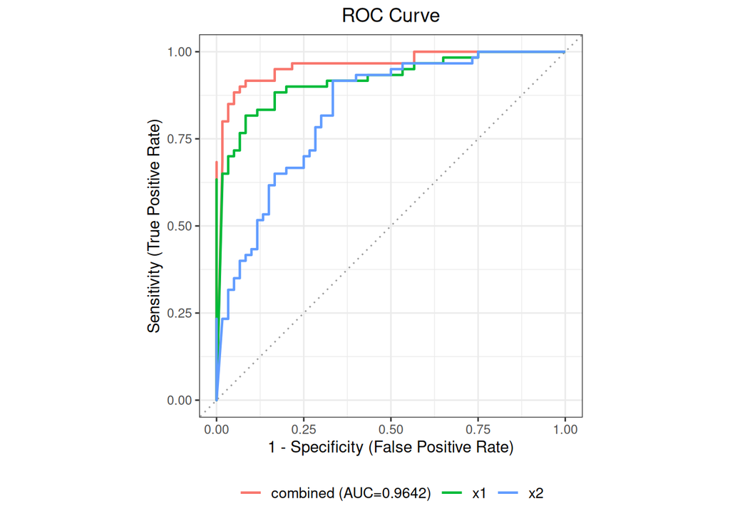

```r
plot(ro2, mlr = "all")
```

`plot(ro2, mlr="all")` draws the ROC curves of each single marker and the joint model together for comparison.

## 3.5 Predicting New Samples

```r
predict(ro2, newdata = data.frame(x1 = c(7, 12), x2 = c(16, 21)))
```

|  | x1 | x2 | pred_prob | pred_se | ci_lower | ci_upper | pred_class |
| --- | --- | --- | --- | --- | --- | --- | --- |
| 1 | 7 | 16 | 0.1200103 | 0.05313595 | 0.04840777 | 0.2677265 | 0 |
| 2 | 12 | 21 | 0.9781557 | 0.01751040 | 0.89984790 | 0.9955390 | 1 |

`predict()` returns each predictor variable, the positive probability (`pred_prob`), the standard error and confidence interval, and the predicted class (`pred_class`) at the default threshold of 0.5. The two cases obtain positive probabilities of 0.12 and 0.98, respectively, consistent with the expected direction.

> **Parameter notes:** When the column names of `newdata` differ from those used in modeling, map them with the named vector `column_map` (for example `column_map = c(new_x1 = "x1")`). If the object contains multiple models, `predict()` must specify the model name with `mlr`.

## 3.6 Summary

```r
summary(ro2)
```

```
#>
#> ROC Analysis -- Summary
#> --------------------------------------------------
#>
#> ROC Analysis
#>   Data class:        data.frame
#>   Total rows:        120
#>   Complete cases:    120
#>   Reference:         ref (binary)
#>   Positive / Neg:    60 / 60
#>   Evaluation cols:   2  (x1, x2)
#>   Duplicate IDs:     none
#>
#> Analysis slots:
#>     [ ] Describe
#>     [x] AUC
#>     [ ] Cutoff
#>     [x] MLR
#>
#>
#> AUC Table
#>   Column               AUC          95% CI  Direction
#>   ------------------------------------------------------------
#>   x1                0.9219  [0.8712, 0.9727]       geq
#>   x2                0.8322  [0.7587, 0.9057]       geq
#>
#> MLR Results
#>
#> Multivariate Logistic Regression (combined)
#>   --------------------------------------------------
#>   Formula: reference_binary ~ x1 + x2
#>   n = 120  (positive = 60, negative = 60)
#>   AUC = 0.9642  [0.9298, 0.9985]
#>
#>   Coefficients:
#>                    Estimate Std. Error   z value     Pr(>|z|)
#>     (Intercept) -13.6586717  2.7569949 -4.954188 7.263286e-07
#>     x1            0.7638502  0.1549103  4.930919 8.184356e-07
#>     x2            0.3949617  0.1064673  3.709700 2.075049e-04
#>
#>   * Note: AUC is evaluated on the same data used for fitting;
#>     the estimate may be optimistic.
```

# 4 Key Points for Interpreting Results

1. **Joint gain**: A joint AUC higher than each single marker only indicates that the linear combination provides a gain; whether it is a significant improvement should be judged with the confidence interval and clinical decision needs.
2. **Apparent performance**: The AUC on the training data is an optimistic estimate; it must be re-estimated on an independent validation set to avoid overfitting misjudgment.
3. **Collinearity and separation**: When markers are highly correlated or perfectly separated, logistic regression may be unstable or fail to converge.
4. **Event count**: A multivariate model needs a sufficient number of events per parameter; use caution when events are too few.
5. **Cutoff and decision**: The final judgment threshold of the joint score should combine clinical costs and the protocol, not be limited to the default 0.5.
6. **Variable selection**: `mlr()` fits a given set of markers in one call; comparisons of multiple variable sets should be pre-specified in the protocol to avoid repeated trial and error.